# Análisis Datos Students | Varhulik & Loncarica

Informe de resultados académicos

Análisis exploratorio del dataset Students

Autores/as

Afiliación

Melina Ayelen Varhulik

Universidad X

Maria Trinidad Loncarica

Universidad X

Fecha de publicación

1 de marzo de 2026

Resumen

Este informe presenta el análisis estadístico del dataset Students, incluyendo visualizaciones y modelos.

Palabras clave

educación, estadística, R, análisis

# 1 Análisis: *Students Habits Performance*

En el presente trabajo se llevara a cabo un analisis del conjunto de datos *“student_habits_performance.csv”* , el cual contiene información detallada sobre los habitos de mas de 800 alumnos universitarios.

### 1.0.1 Nuestra Hipotesis:

*Los habitos de la vida de los estudiantes ( horas de estudio, sueño, uso de redes sociales y salud mental, etc… ) tienen un impacto significativo en su rendimiento academico ( exam_score ).*

#### 1.0.1.1 1. ¿Las horas de estudio diarias se relacionan con el puntaje del examen?

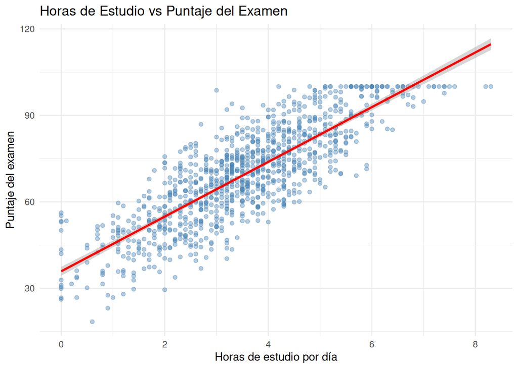

- *Qué muestra:*
  - Cada punto representa un estudiante. El eje X indica cuántas horas estudia por día y el eje Y su puntaje. La línea roja muestra la tendencia general.
- *Conclusión:*
  - Existe una *relación positiva*: a más horas de estudio, mayor puntaje. Es probablemente la variable con impacto más directo y visible en el rendimiento.

#### 1.0.1.2 2. ¿El tiempo en redes sociales afecta negativamente el rendimiento?

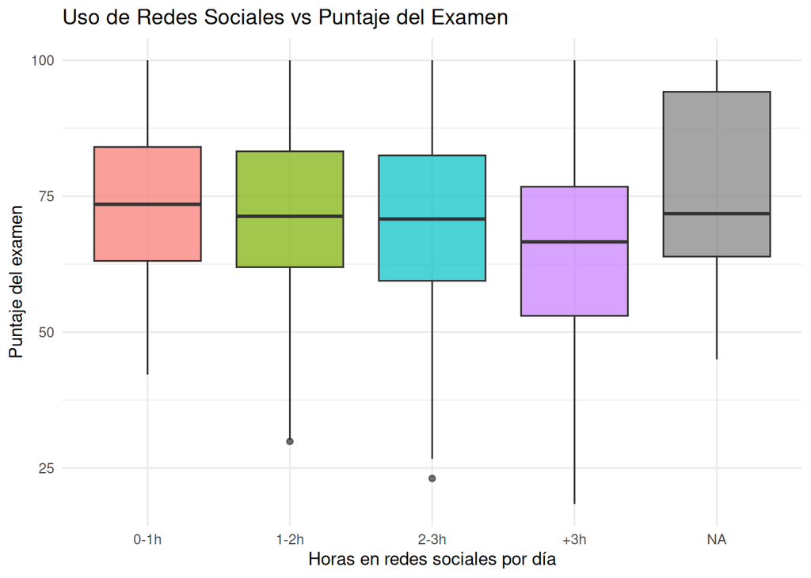

#### 1.0.1.3 3. ¿La calidad del sueño (horas dormidas) influye en el rendimiento?

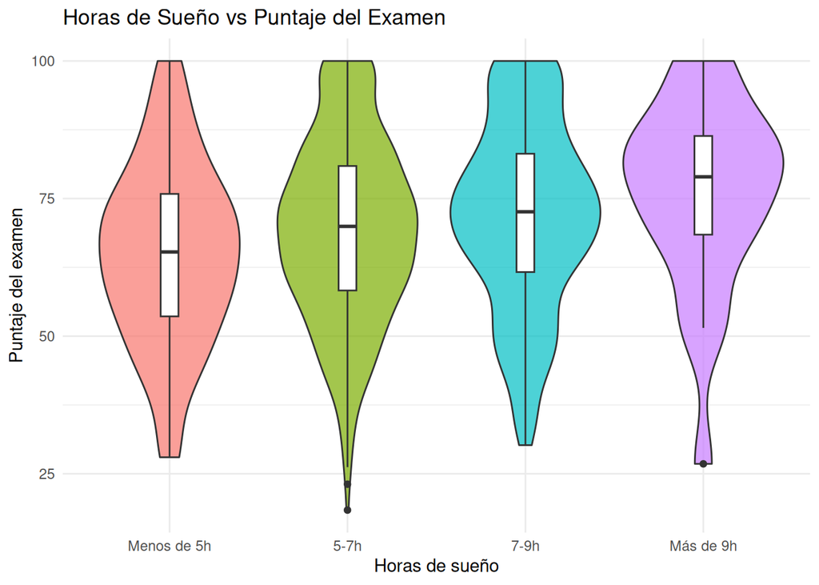

#### 1.0.1.4 4. ¿La salud mental impacta en el rendimiento académico?

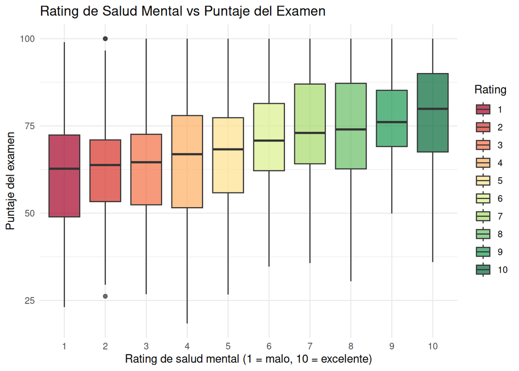

- *Qué muestra:*
  - Cada caja representa un nivel de salud mental (1 = muy mala, 10 = excelente). La paleta de colores va de rojo (malo) a verde (excelente).
- *Conclusión:*
  - Las cajas verdes (ratings altos) están más arriba que las rojas, se concluye que *mejor salud mental se asocia con mayor rendimiento académico*. Esto también puede reflejar que los estudiantes que rinden bien tienen menos estrés.

#### 1.0.1.5 5. ¿La dieta y el ejercicio se relacionan con el rendimiento?

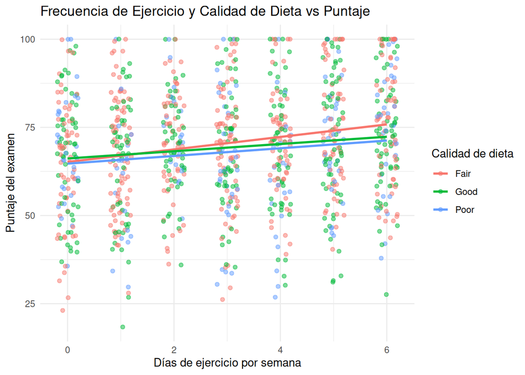

- *Qué muestra:*
  - El eje X es la frecuencia de ejercicio semanal, el eje Y el puntaje. Cada color representa una calidad de dieta (Buena, Regular, Mala). Las líneas muestran la tendencia de cada grupo.
- *Conclusión:*
  - La línea del grupo “Good” (dieta buena) no está por encima de las demás ( pese a subir con el ejercicio ), se concluye, por ende, que *combinar buena dieta con ejercicio regular no favorece drasticamente el rendimiento.*
    - Permite comparar si el ejercicio ayuda por igual en todos los grupos de dieta.

#### 1.0.1.6 6. ¿Los estudiantes con trabajo a tiempo parcial rinden menos?

```
    Welch Two Sample t-test

data:  con_trabajo and sin_trabajo
t = -0.8523, df = 346.73, p-value = 0.3946
alternative hypothesis: true difference in means is not equal to 0
95 percent confidence interval:
 -3.616297  1.429687
sample estimates:
mean of x mean of y
 68.74326  69.83656
```

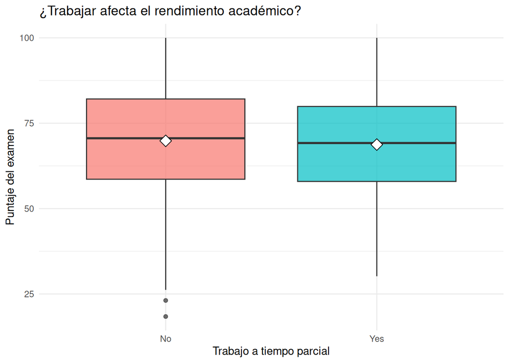

( + POSIBLES PREGUNTAS )

¿El nivel educativo de los padres influye en el puntaje?

¿Qué hábito impacta MÁS en el puntaje?

¿Cómo es el estudiante con alto y bajo puntaje?